# prosperLoanData

Ubirajara Theodoro Schier

17 de julho de 2017

# 1. REQUISITOS DO PROJETO

1.1. Uma análise passo a passo da análise e exploração dos dados.

1. Cabeçalhos e texto devem organizar seus pensamentos e refletir sua análise conforme você explora os dados.
2. Gráficos na sua análise não precisam ser rebuscados com rótulos, unidades e títulos; estes gráficos são exploratório (rápidos e simples). Eles devem, contudo, ser dos tipos apropriados e efetivamente representar a informação que você deseja obter a partir deles.
3. Você pode iterar sobre um gráfico no mesmo código R, mas você não precisa mostrar todas as iterações na sua análise.

1.2. Uma seção no final chamada “Gráficos Finais e Sumário”

Você irá escolher três gráficos da sua análise para polir e compartilhar nesta seção. Os três gráficos deverão demonstrar diferentes tendências e devem ser detalhados com os rótulos apropriados, unidades e títulos.

1.3. Uma seção final chamada “Reflexão”

Esta deve conter algumas frases sobre suas dificuldades, sucessos, e idéias para explorações futures neste mesmo conjunto de dados.

# 2. PREPARAÇÃO DO AMBIENTE E DO CONJUNTO DE DADOS

## 2.1. Carga, Limpeza e Transformações do conjunto de dados

```
## [1] "> Ações realizadas nesta etapa:"
```

```
## [1] "> carga do conjunto de dados prosperLoanData.csv"
```

```
## [1] "> remoção de registros duplicados"
```

```
## # A tibble: 827 x 2
##                    LoanKey     n
##                     <fctr> <int>
##  1 001D370202065948445765E     2
##  2 009C36959125842600757B0     2
##  3 01663704101754715CF7C56     2
##  4 017637048068403015E470D     2
##  5 01C83707282210922790778     2
##  6 02163700809231365A56A1C     2
##  7 0224369791751850396C2F3     2
##  8 0275370118102352450205B     2
##  9 02983704628886994482743     2
## 10 02D137079845719197ACFE8     2
## # ... with 817 more rows
```

```
## [1] "> reordenação do campo ProsperRating..Alpha."
```

```
## [1] "> reordenação do campo IncomeRange"
```

```
## [1] "> reordenação do campo LoanOriginationQuarter"
```

```
## [1] "> conversão do campo ListingCreationDate para o formato DateTime"
```

```
## [1] "> conversão do campo ListingCreationDate para o formato DateTime"
```

```
## [1] "> conversão do campo LstCDate para o formato DateMonth"
```

```
## [1] "> conversão do campo FirstRecordedCreditLine para o formato DateTime"
```

```
## [1] "> Conversão do campo Term de numérico para um novo campo vetorial"
```

```
## [1] "> criação do campo DaysFromFirstRecCredLine que acumula o tempo em dias \n     desde o primeiro crédito"
```

```
## [1] "> criação do campo CreditScoreRangeMean para simplificação das\n     análises"
```

```
## [1] "> criação do campo FLoanOriginalAmount (versão fatorial do campo \n     LoanOriginalAmount)"
```

```
## [1] "> criação do campo FInvestors (versão fatorial do campo Investors"
```

```
## [1] "> criação do campo FBorrowerAPR (versão fatorial do campo BorrowerAPR"
```

```
## [1] "> criação do campo ProsperGain (ganho da financeira)"
```

```
## [1] "> filtrando os registros com LoanStatus=Completed"
```

```
## [1] "> filtrando os registros com DebtToIncomeRatio<10"
```

```
## [1] "> filtrando os registros posteriores à 2005 (22 movimentos) e anteriores à 2014 (66 movimentos)"
```

```r
#table(pld$IncomeRange)
```

## 2.2. Seleção das variáveis de interesse

> O objetivo geral nesta etapa é selecionar as variáveis de interesse (LVI) que possam caracterizar alguma relação entre os principais indicadores financeiros relativos ao mutuário e à taxa de juros proposta no fechamento do empréstimo.

### Caracterização do Conjunto de Dados

[output not shown]

```
## [1] "> Número de registros do conjuntos de dados:  35116"
```

```
## [1] "> Relação das variáveis disponíveis no conjunto de dados:"
```

```
## 'data.frame':    35116 obs. of  91 variables:
##  $ ListingKey                         : Factor w/ 113066 levels "00003546482094282EF90E5",..: 7180 6647 6720 7161 6825 6827 6840 6880 7420 6919 ...
##  $ ListingNumber                      : int  193129 81716 213551 241498 713131 463083 555213 478891 24135 378497 ...
##  $ ListingCreationDate                : Factor w/ 113064 levels "2005-11-09 20:44:28.847000000",..: 14184 6429 15374 16841 69285 33837 49717 35437 1930 26897 ...
##  $ CreditGrade                        : Factor w/ 9 levels "","A","AA","B",..: 5 8 5 6 1 1 1 1 4 5 ...
##  $ Term                               : int  36 36 36 36 60 36 36 36 36 36 ...
##  $ LoanStatus                         : Factor w/ 12 levels "Cancelled","Chargedoff",..: 3 3 3 3 3 3 3 3 3 3 ...
##  $ ClosedDate                         : Factor w/ 2803 levels "","2005-11-25 00:00:00",..: 1138 1263 538 1623 2664 2553 2357 2359 1207 1306 ...
##  $ BorrowerAPR                        : num  0.165 0.283 0.15 0.215 0.307 ...
##  $ BorrowerRate                       : num  0.158 0.275 0.133 0.207 0.281 ...
##  $ LenderYield                        : num  0.138 0.24 0.122 0.198 0.271 ...
##  $ EstimatedEffectiveYield            : num  NA NA NA NA 0.247 ...
##  $ EstimatedLoss                      : num  NA NA NA NA 0.122 ...
##  $ EstimatedReturn                    : num  NA NA NA NA 0.125 ...
##  $ ProsperRating..numeric.            : int  NA NA NA NA 2 6 6 7 NA NA ...
```

[output cut: 77 more lines]

### Pré-seleção e criação da lsita de variáveis de interesse (LVI)

> Nesta etapa serão armazenadas em uma lista apenas as variáveis do dataset que atendam à dois critérios: 1- percentual de registros inválidos 2- número de categorias de classificação (válido apenas para variáveis fatoriais) Como uma relação completa das variáveis disponíveis no conjunto de dados já foi apresentado, relacionaremos abaixo apenas as variáveis que não atenderam aos requisitos acima e que portanto não foram inseridas na LVI.

```
## [1] "> Pré-Seleção de variáveis:"
```

```
## [1] "Critério1: Percentual de registros inválidos < 10 %"
```

```
## [1] "Critério2: Variáveis fatoriais com até  24 classes"
```

```
## [1] "> ListingKey : variável descartada   - Motivo: núm. valores únicos   =  35116"
## [1] "> ListingCreationDate : variável descartada   - Motivo: núm. valores únicos   =  35116"
## [1] "> CreditGrade : variável descartada   - Motivo: % registros inválidos =  50.48"
## [1] "> LoanStatus : variável descartada   - Motivo: núm. valores únicos   =  1"
## [1] "> ClosedDate : variável descartada   - Motivo: núm. valores únicos   =  2513"
## [1] "> EstimatedEffectiveYield : variável descartada   - Motivo: % registros inválidos =  49.84"
## [1] "> EstimatedLoss : variável descartada   - Motivo: % registros inválidos =  49.84"
## [1] "> EstimatedReturn : variável descartada   - Motivo: % registros inválidos =  49.84"
## [1] "> ProsperRating..numeric. : variável descartada   - Motivo: % registros inválidos =  49.84"
## [1] "> ProsperRating..Alpha. : variável descartada   - Motivo: % registros inválidos =  55.84"
## [1] "> BorrowerState : variável descartada   - Motivo: núm. valores únicos   =  52"
## [1] "> Occupation : variável descartada   - Motivo: núm. valores únicos   =  68"
## [1] "> EmploymentStatusDuration : variável descartada   - Motivo: % registros inválidos =  12.58"
## [1] "> GroupKey : variável descartada   - Motivo: núm. valores únicos   =  590"
## [1] "> DateCreditPulled : variável descartada   - Motivo: núm. valores únicos   =  35114"
```

[output cut: 29 more lines]

```
## [1] ">  IncomeRange : variável adicionada - Motivo:  Reinserida, por que pois após remover os registros iguais à Not-displayed o percentual de missing values ficou maior que 10% (12,8%)."
```

### Remoção de variáveis secundárias

> Nesta etapa, em função do alto número de variáveis do conjunto de dados, serão removidas da LVI as variáveis que foram consideradas sem uma relevância significativa em um primeiro momento. Entretanto, no decorrer das análises, estas variáveis estarão sendo sempre reavaliadas, permanecendo na lista se necessárias.

```
## [1] "> Relação de variáveis secundárias descartadas"
```

```
## [1] "- Motivo:  variável sem relevância significativa ao tema investigado."
```

```
## [1] ">  CurrentlyInGroup : variável descartada "
```

```
## [1] ">  ListingNumber : variável descartada "
```

```
## [1] ">  Term : variável descartada "
```

```
## [1] ">  OpenRevolvingAccounts : variável descartada "
```

```
## [1] ">  OpenRevolvingMonthlyPayment : variável descartada "
```

```
## [1] ">  InquiriesLast6Months : variável descartada "
```

```
## [1] ">  CurrentDelinquencies : variável descartada "
```

```
## [1] ">  PublicRecordsLast10Years : variável descartada "
```

```
## [1] ">  StatedMonthlyIncome : variável descartada "
```

```
## [1] ">  LoanMonthsSinceOrigination : variável descartada "
```

```
## [1] ">  LoanNumber : variável descartada "
```

```
## [1] ">  LP_CustomerPayments : variável descartada "
```

```
## [1] ">  LP_CustomerPrincipalPayments : variável descartada "
```

```
## [1] ">  LP_InterestandFees : variável descartada "
```

```
## [1] ">  LP_ServiceFees : variável descartada "
```

```
## [1] ">  LP_CollectionFees : variável descartada "
```

```
## [1] ">  PercentFunded : variável descartada "
```

```
## [1] ">  Recommendations : variável descartada "
```

```
## [1] ">  InvestmentFromFriendsCount : variável descartada "
```

```
## [1] ">  InvestmentFromFriendsAmount : variável descartada "
```

```
## [1] ">  CreditScoreRangeLower : variável descartada "
```

```
## [1] ">  CreditScoreRangeUpper : variável descartada "
```

```
## [1] ">  BorrowerRate : variável descartada "
```

```
## [1] ">  LenderYield : variável descartada "
```

```
## [1] ">  MonthlyLoanPayment : variável descartada "
```

```
## [1] ">  LstCDate : variável descartada "
```

```
## [1] ">  LstCMonth : variável descartada "
```

```
## [1] ">  FirstRecCredLine : variável descartada "
```

```
## [1] ">  ListingCategory..numeric. : variável descartada "
```

### Relação das variáveis de interesse selecionadas para análise

> Nesta etapa apresentamos a relação final da LVI com o nome de cada variável e seu tipo. Serão estas as variáveis que serão utilizadas nas análises seguintes.

```
##  [1] "[ n ] BorrowerAPR"                "[ f ] EmploymentStatus"
##  [3] "[ f ] IsBorrowerHomeowner"        "[ n ] TotalCreditLinespast7years"
##  [5] "[ n ] TotalInquiries"             "[ n ] DelinquenciesLast7Years"
##  [7] "[ n ] DebtToIncomeRatio"          "[ f ] IncomeVerifiable"
##  [9] "[ n ] LoanOriginalAmount"         "[ n ] Investors"
## [11] "[ f ] FLoanOriginationYear"       "[ f ] FTerm"
## [13] "[ n ] DaysFromFirstRecCredLine"   "[ n ] CreditScoreRangeMean"
## [15] "[ f ] FLoanOriginalAmount"        "[ f ] FInvestors"
## [17] "[ f ] FBorrowerAPR"               "[ n ] ProsperGain"
## [19] "[ f ] IncomeRange"
```

# 3. ANÁLISE E SESSÃO DE GRÁFICOS UNIVARIADOS

## 3.1. Distribuição das variáveis de interesse fatoriais

> Nesta etapa analisaremos a distribuição das ocorrências das variáveis de interesse fatoriais (categóricas) que foram selecionadas a fim de analisarmos o conteúdo e frequência das informações categóricas disponíveis.

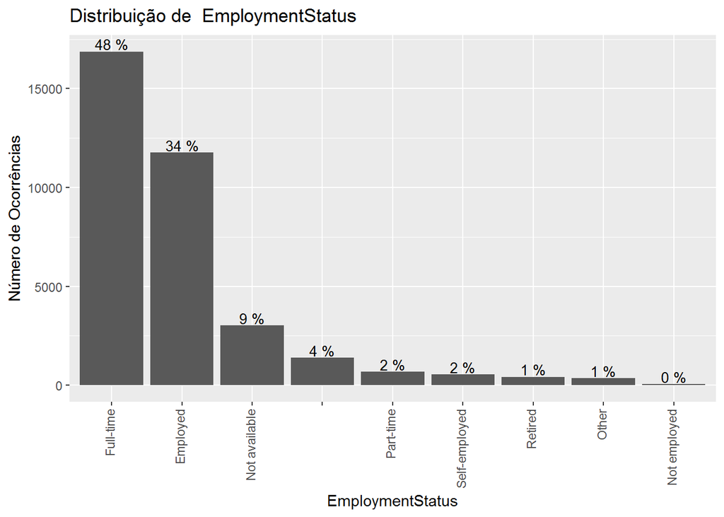

```
##
## [1] "> EmploymentStatus - Observações:  Cerca de 82% dos empréstimos foram destinados à pessoas empregadas ou com trabalho full-time."
```

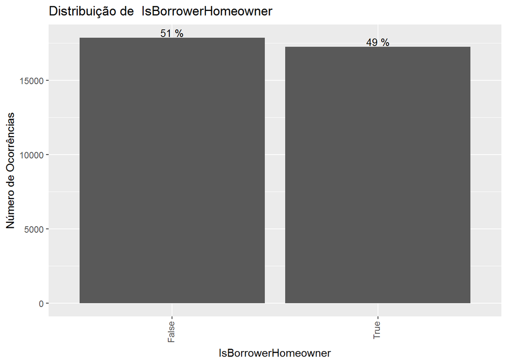

```
##
## [1] "> IsBorrowerHomeowner - Observações:  O percentual de empréstimos concedidos para pessoas proprietárias de sua residência foi aproximadamente igual ao de pessoas sem residência própria."
```

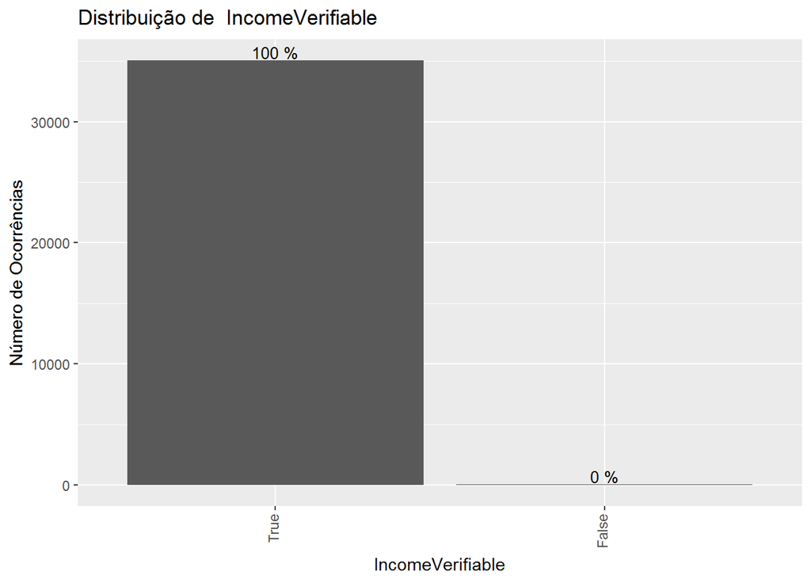

```
##
## [1] "> IncomeVerifiable - Observações:  Variável sem variância (constante) para o sub-conjunto de dados analisado (LoanStatus=Completed)."
```

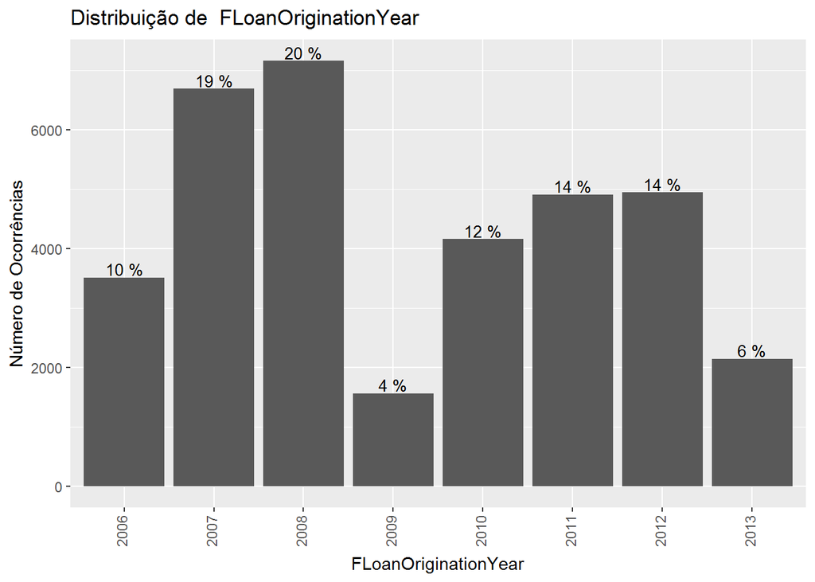

```
##
## [1] "> FLoanOriginationYear - Observações:  Percebe-se quedas significativas no volume de empréstimo concedidos nos anos de 2009 e 2013."
```

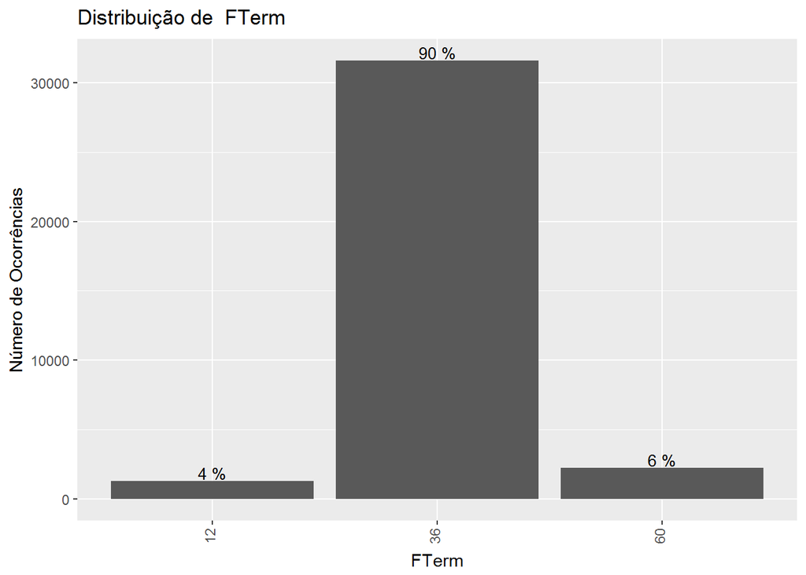

```
##
## [1] "> FTerm - Observações:  A grande maioria dos empréstimos concedidos (90%) tiveram prazo de pagamento de 3 anos."
```

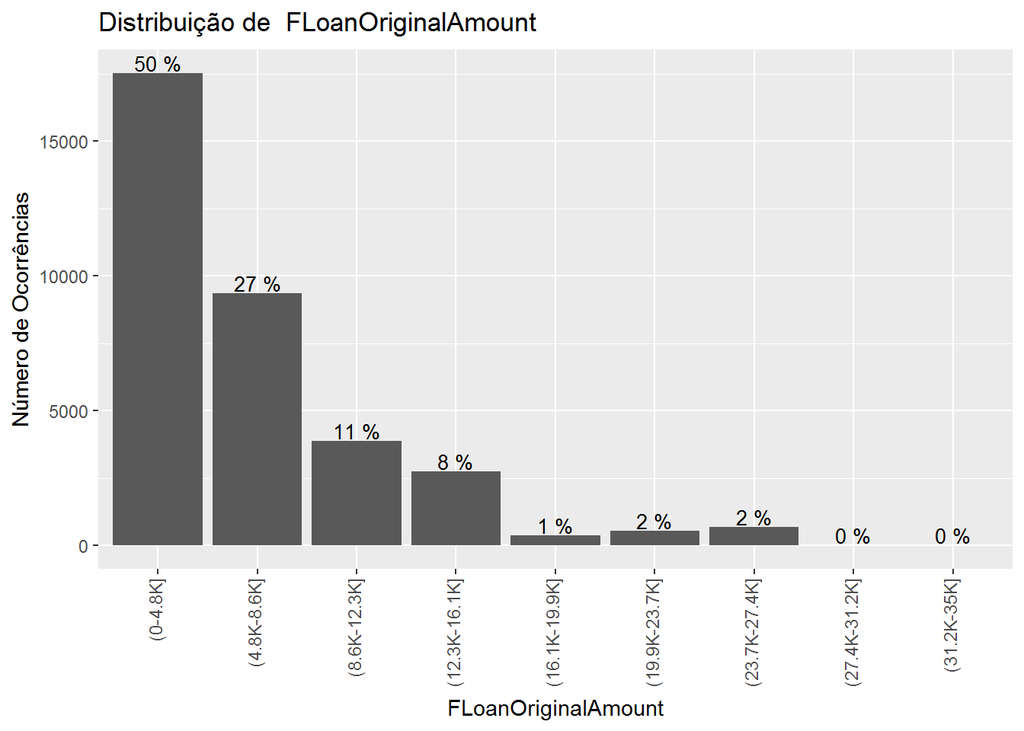

```
##
## [1] "> FLoanOriginalAmount - Observações:  O volume de empréstimos concedidos aumenta quanto menor o valor do empréstimo solicitado, diferentemente do esperado, que seria de se concentrar em torno do valor médio."
```

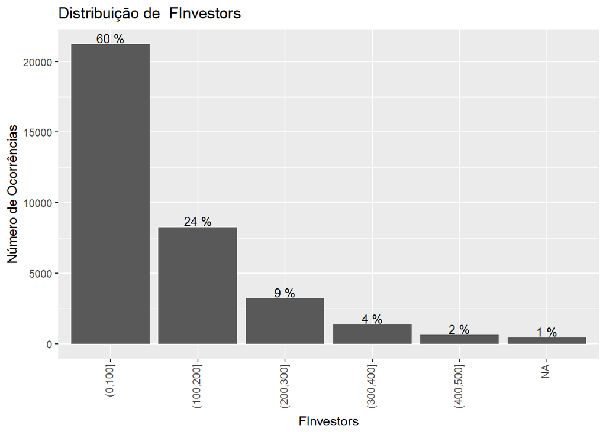

[output not shown]

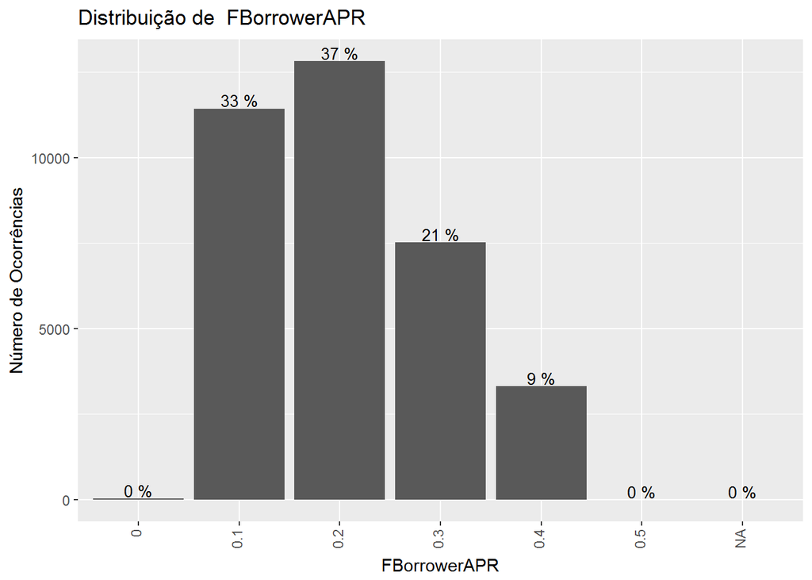

```
##
## [1] "> FBorrowerAPR - Observações:  Percebe-se uma grande concentração dos emrpréstimos com taxa anuais de juros aprovadas entre 0,1 e 0,299 (69%)."
```

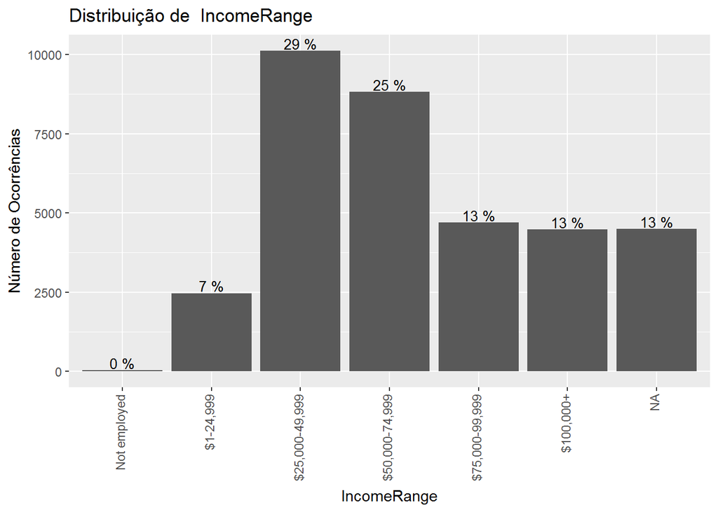

```
##
## [1] "> IncomeRange - Observações:  Cerca de 54% dos empréstimos foram concedidos à pessoas com rendimento na faixa entre 25 e 75 mil dólares."
```

### Atualização da lista de variáveis de interesse

> Após analisadas as distribuições do item anterior, será feito nessa etapa uma atualização da LVI, removendo e/ou inserindo variáveis conforme necessidade.

```
## [1] ">  IncomeVerifiable : variável descartada - Motivo:  Variável sem variância (constante) para o sub-conjunto de dados analisado (LoanStatus=Completed)."
```

## 3.2. Distribuição das variáveis de interesse numéricas

> Nesta etapa analisaremos a distribuição das ocorrências das variáveis de interesse numéricas que foram selecionadas a fim de analisarmos a forma de distribuição da frequência das informações disponíveis.

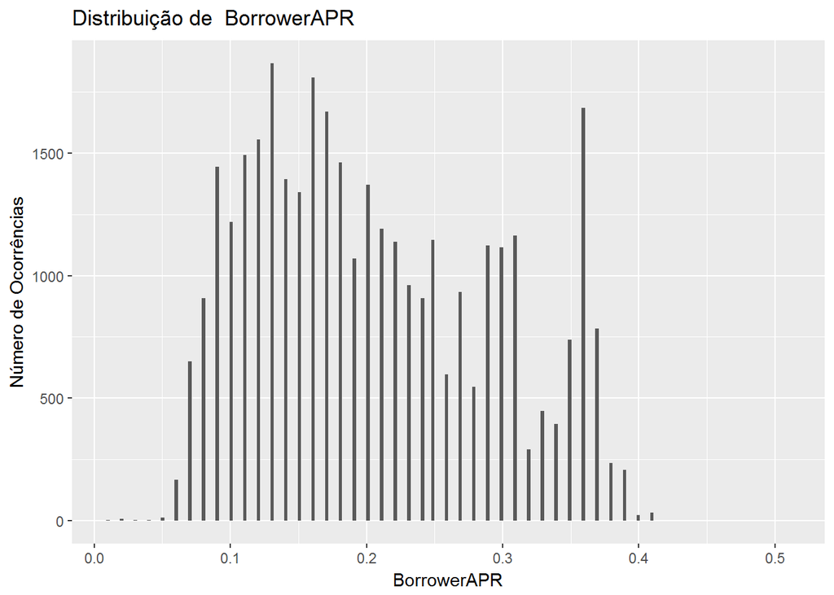

[output not shown]

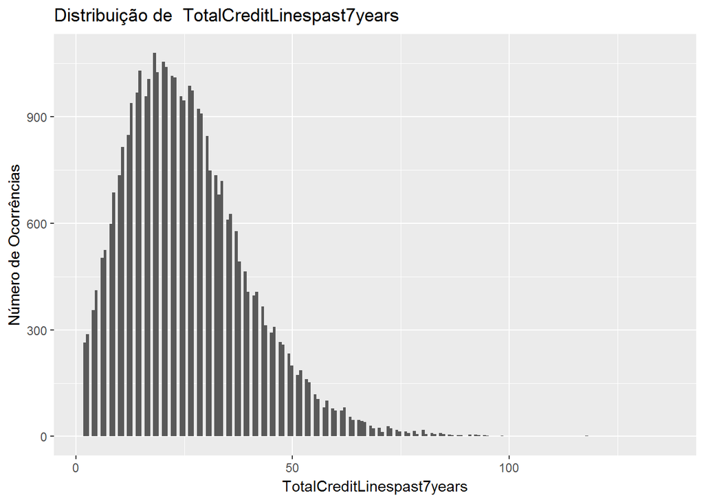

```
##
## [1] "> TotalCreditLinespast7years - Observações:  Este indicador apresenta uma distribuição normal, deslocada à esquerda, pois o mesmo não poderia apresentar valores negativos."
##
## [1] "> TotalCreditLinespast7years - Estatísticas: "
## [1] "- Valor Mín./Máx.:  2 / 136"
## [1] "- Média          :  25.667"
## [1] "- Mediana        :  24"
## [1] "- Desvio Padrão  :  14.115"
```

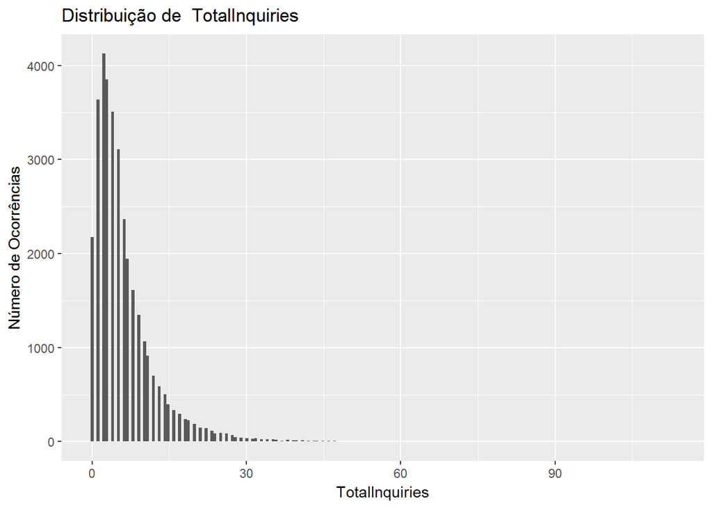

```
##
## [1] "> TotalInquiries - Observações:  A distribuição desta variável não está muito clara, pois confunde o comportamento de uma distribuição normal com uma exponencial negativa. No item seguinte o gráfico será transformado para melhor visualização."
##
## [1] "> TotalInquiries - Estatísticas: "
## [1] "- Valor Mín./Máx.:  0 / 113"
## [1] "- Média          :  6.243"
## [1] "- Mediana        :  4"
## [1] "- Desvio Padrão  :  6.559"
```

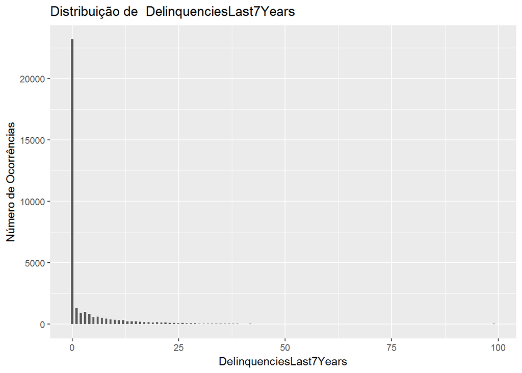

```
##
## [1] "> DelinquenciesLast7Years - Observações:  Esta variável possui uma grande concentração de ocorrências em torno do valor 0. Para uma melhor visualização será preciso transformar a variável a fim de verificar a distribuição nos valores acima de 0 no eixo X."
##
## [1] "> DelinquenciesLast7Years - Estatísticas: "
## [1] "- Valor Mín./Máx.:  0 / 99"
## [1] "- Média          :  4.04"
## [1] "- Mediana        :  0"
## [1] "- Desvio Padrão  :  9.974"
```

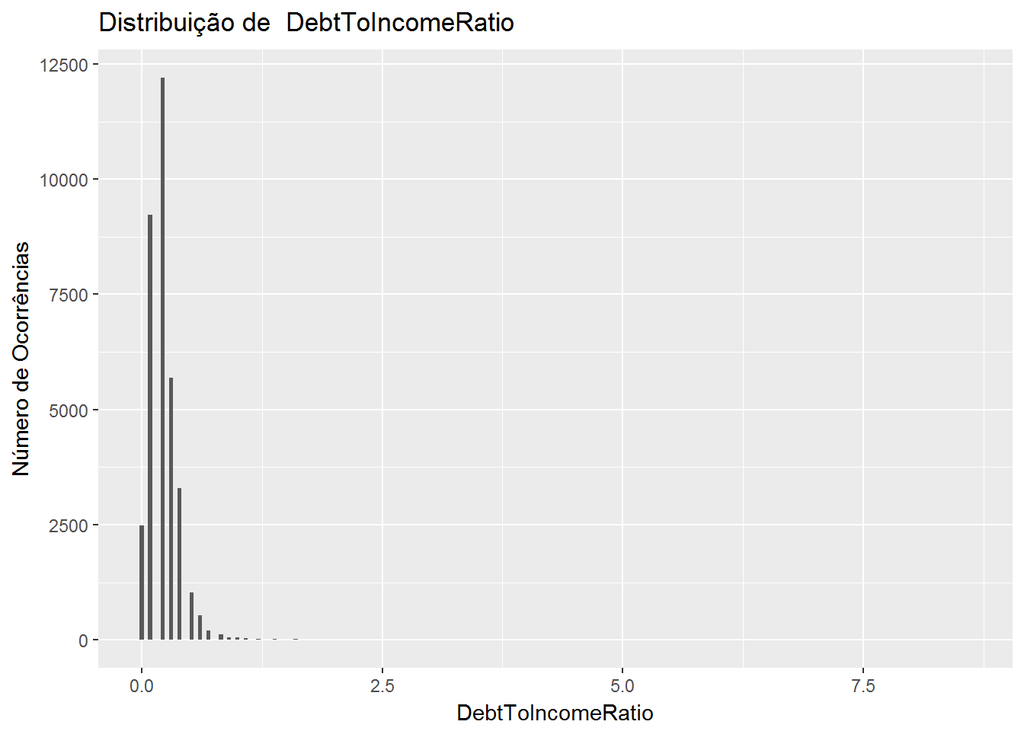

```
##
## [1] "> DebtToIncomeRatio - Observações:  A distribuição desta variável não está muito clara, pois confunde o comportamento de uma distribuição normal com uma exponencial negativa. No item seguinte o gráfico será transformado para melhor visualização."
##
## [1] "> DebtToIncomeRatio - Estatísticas: "
## [1] "- Valor Mín./Máx.:  0 / 8.63"
## [1] "- Média          :  0.23"
## [1] "- Mediana        :  0.19"
## [1] "- Desvio Padrão  :  0.248"
```

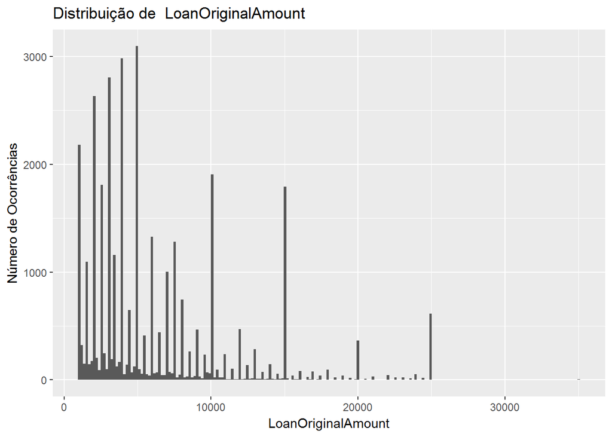

```
##
## [1] "> LoanOriginalAmount - Observações:  os valores de empréstimos apresentam picos de concentração em determinados pontos do gráfico. Possivelmente valores cheios de empréstimos tendem a ser mais requisitados."
##
## [1] "> LoanOriginalAmount - Estatísticas: "
## [1] "- Valor Mín./Máx.:  1000 / 35000"
## [1] "- Média          :  6257.787"
## [1] "- Mediana        :  4800"
## [1] "- Desvio Padrão  :  5118.819"
```

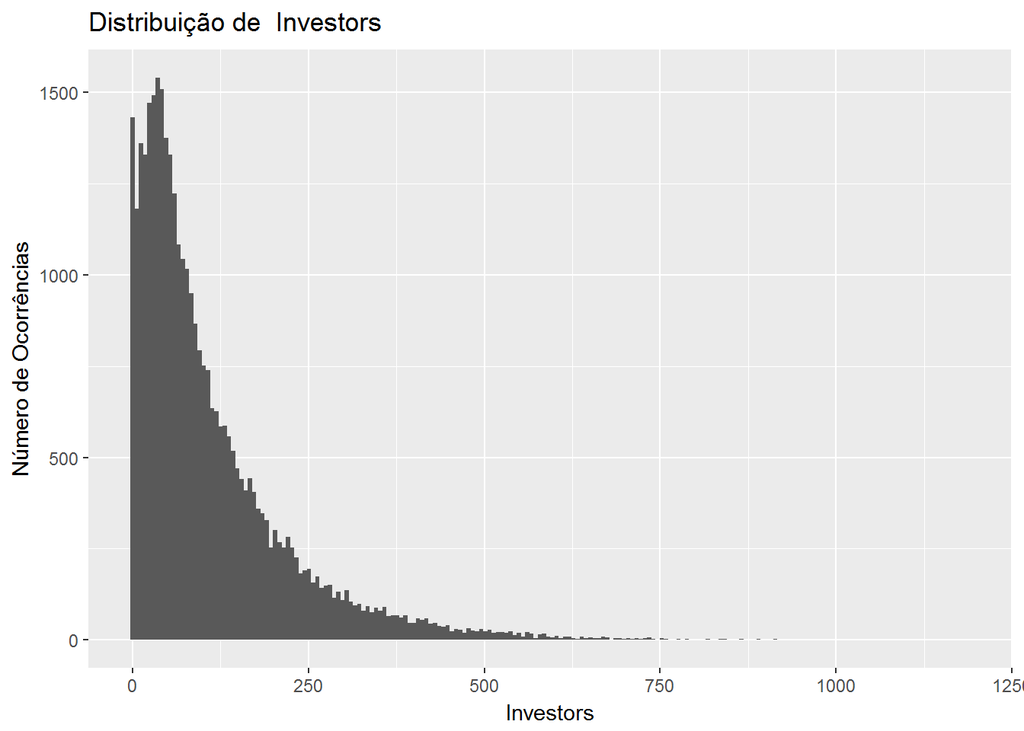

```
##
## [1] "> Investors - Observações:  Na distribuição do número de investidores, pode-se perceber uma distribuição do tipo exponencial negativa onde diminuem as ocorrências de empréstimos para maiores número de investidores."
##
## [1] "> Investors - Estatísticas: "
## [1] "- Valor Mín./Máx.:  1 / 1189"
## [1] "- Média          :  110.847"
## [1] "- Mediana        :  76"
## [1] "- Desvio Padrão  :  111.662"
```

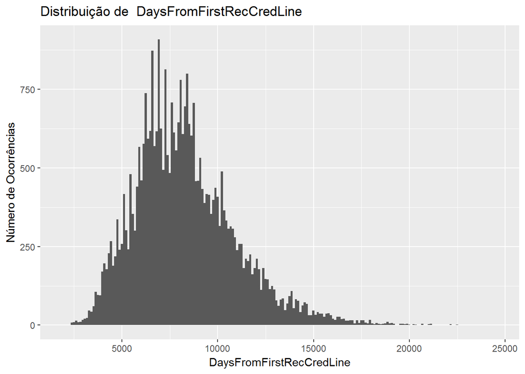

```
##
## [1] "> DaysFromFirstRecCredLine - Observações:  Nota-se que a distribuição desta variável segue uma distribuição normal, apesar da presença de determinados picos de concentração, possivelmente decorrentes de prazos específicos para encaminhamento dos empréstimos."
##
## [1] "> DaysFromFirstRecCredLine - Estatísticas: "
## [1] "- Valor Mín./Máx.:  1902 / 24505"
## [1] "- Média          :  8311.338"
## [1] "- Mediana        :  8005"
## [1] "- Desvio Padrão  :  2633.144"
```

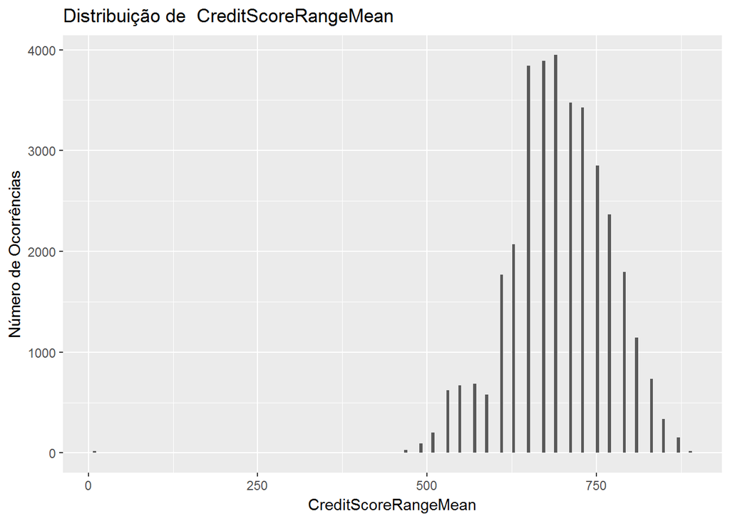

```
##
## [1] "> CreditScoreRangeMean - Observações:  Repare-se nesta variável uma distribuição que se assemelha à uma distribuição normal, concentrando os valores em torno da média."
##
## [1] "> CreditScoreRangeMean - Estatísticas: "
## [1] "- Valor Mín./Máx.:  9.5 / 889.5"
## [1] "- Média          :  694.256"
## [1] "- Mediana        :  689.5"
## [1] "- Desvio Padrão  :  73.419"
```

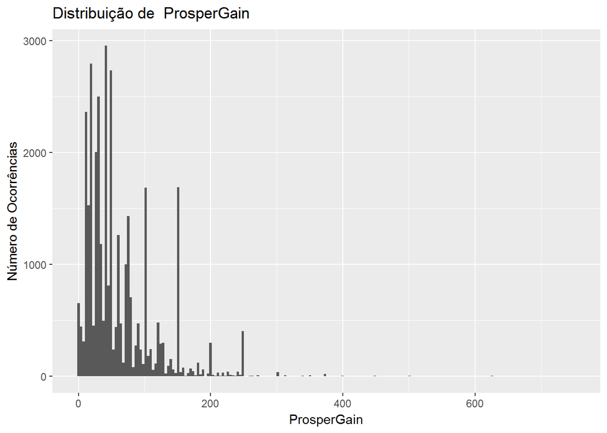

```
##
## [1] "> ProsperGain - Observações:  Nesta variável perce-se a dificuldade de se identificar uma distribuição clara, pois o ganho obtido em cada empréstimo varia unicamente em função do valor do empréstimo em si."
##
## [1] "> ProsperGain - Estatísticas: "
## [1] "- Valor Mín./Máx.:  0 / 750"
## [1] "- Média          :  60.36"
## [1] "- Mediana        :  42"
## [1] "- Desvio Padrão  :  53.687"
```

### Distribuições transformadas

> Nesta etapa serão replotados os gráficos do item anterior em outra escala para possibilitar uma melhor visualização da distribuição.

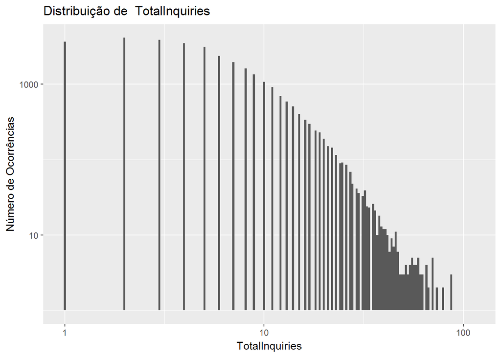

```
##
## [1] "> TotalInquiries - Observações:  Nesta variável podemos observar mais claramente após transformar o eixo X na escala log10, uma distribuição que se assemelha à uma meia normal."
##
## [1] "> TotalInquiries - Estatísticas: "
## [1] "- Valor Mín./Máx.:  0 / 113"
## [1] "- Média          :  6.243"
## [1] "- Mediana        :  4"
## [1] "- Desvio Padrão  :  6.559"
```

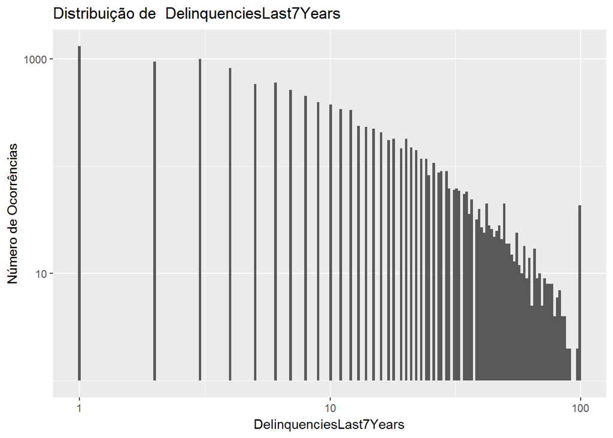

[output not shown]

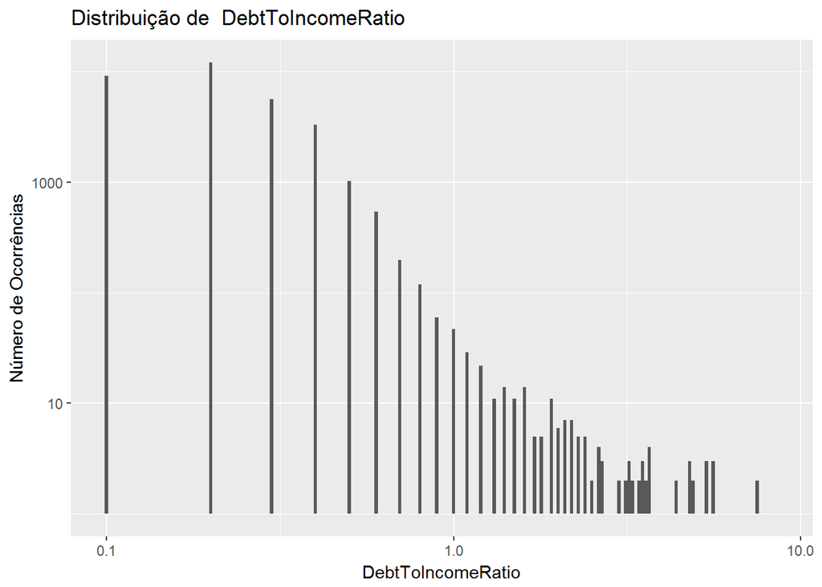

```
##
## [1] "> DebtToIncomeRatio - Observações:  Ao transformarmos a escala de ambox o eixos para log10, é possível observar uma distribuição que se assemelha à uma meia parábola"
##
## [1] "> DebtToIncomeRatio - Estatísticas: "
## [1] "- Valor Mín./Máx.:  0 / 8.63"
## [1] "- Média          :  0.23"
## [1] "- Mediana        :  0.19"
## [1] "- Desvio Padrão  :  0.248"
```

## 3.3. Conclusões

> Atributos de interesse mantidos do conjunto de dados:

Na etapa 2.4. selecionamos as variáveis de interesse que podem ser classificadas nos seguintes grupos:

- informações relativas ao empréstimo (li=loan info)
- condições do Empréstimo (lc=loan conditions)
- informações do Mutuário (bi=borrower info)
- análise de Crédito (ci=credit info)
- situação do Empréstimo (lr=loan results)

A relação final das variáveis de interesse selecionadas encontram-se listadas no item 2.4.5.

> Atributos descartados do conjunto de dados

Durante as etapas 2.4.2. e 2.4.4. foram descartadas as variáveis que:

- Variáveis que apresentaram um percentual de registros inválidos superior à 10%.
- Variáveis secundárias, onde não se reconheceu de que forma estas poderiam agregar valor às análises.
- Variáveis substituídas por uma variável similar criada para facilitar o processamento das análises.
- Variáveis que apresentaram pouca ou quase nenhuma distribuição observada nos gráficos.

> Atributos auxiliares sugeridos

Verificou-se após uma avaliação das variáveis de interesse, que os atributos abaixo sugeridos poderiam complementar positivamente o conjunto de dados:

- idade do mutuário
- renda total familiar
- número de dependentes
- se mora em imóvel próprio ou alugado
- valor do aluguel (quando não proprietário de imóvel)

> Atributos novos criadas à partir do conjunto de dados

Durante a etapa 2.3., para facilitar as análises, foram criados novas variáveis de acordo conforme segue:

- variáveis numéricas convertidas para fatorial
- variáveis contendo o valor médio entre duas variáveis
- variáveis do tipo data contendo o formato datetime adequado

As novas variáveis criadas foram adicicionadas também à lista de variáveis de interesse conforme já listado previamente no item 2.4.5

> Atributos inconsistentes e ações corretivas adotadas

O tratamento de dados foi realizado onde foram tratados as seguintes situações:

- remoção de registros duplicados (871 registros)
- reordenação de campos

# 4: ANÁLISE E SESSÃO DE GRÁFICOS BIVARIADOS

## 4.1. Gráficos de Dispersão entre as variáveis de Resultado numéricas investigadas e demais variáveis (também numéricas)

> Nesta etapa foram selecionadas entre as variáveis numéricas do conjunto de dados, aquelas que possuem maior relevância com o tema investigado. Para cada variável selecionada foram calculadas as correlações com todas as demais variáveis numéricas e estas expostas por meio de gráfico de dispersão quando as correlações apresentaram um coeficiente maior ou igual a 0,5.

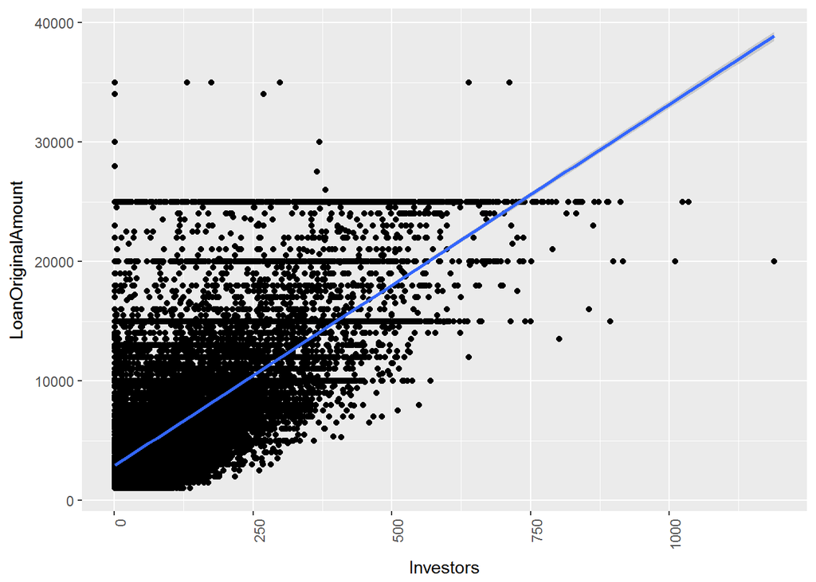

```
## [1] "> Estatísticas de Correlação entre:  LoanOriginalAmount  x  Investors"
## [1] "- Método           :  Pearson's product-moment correlation"
## [1] "- p.value          :  0.66"
## [1] "- Interv.Confiança :  0.654  /  0.666"
##
## [1] "- Observações:  Verifica-se por meio do coeficiente uma correlação moderada, onde é possível observar no gráfico de dispersão a tendência a ser necessário mais investidores para completar o valor total do empréstimo requisitado à medida que aumenta o valor do empréstimo."
```

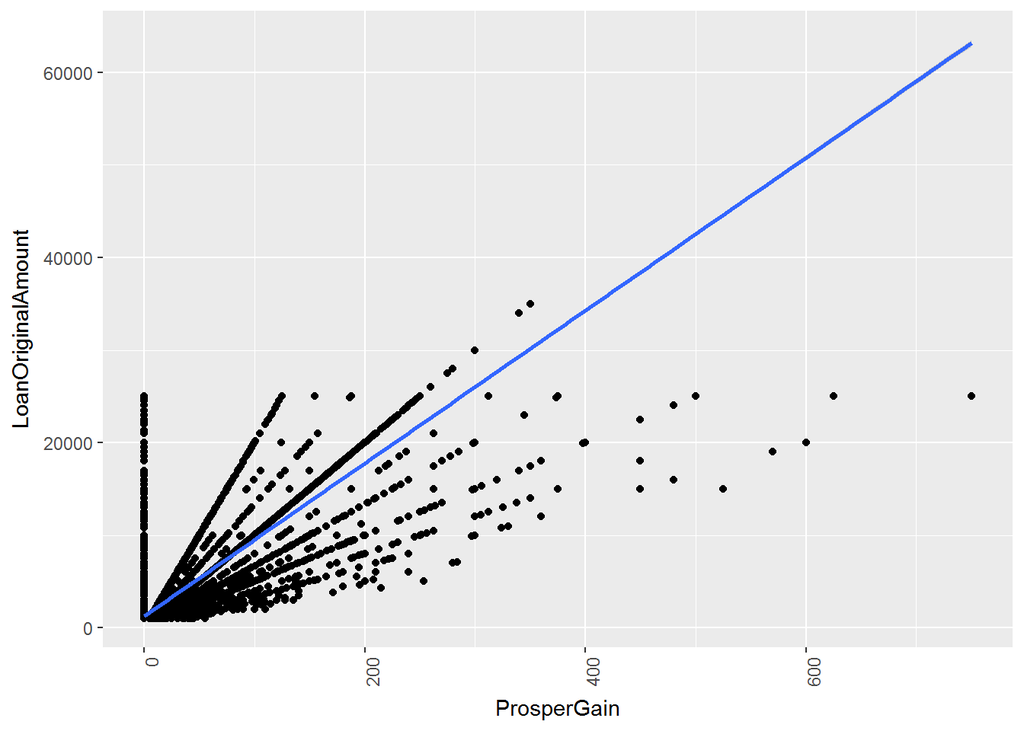

```
## [1] "> Estatísticas de Correlação entre:  LoanOriginalAmount  x  ProsperGain"
## [1] "- Método           :  Pearson's product-moment correlation"
## [1] "- p.value          :  0.865"
## [1] "- Interv.Confiança :  0.863  /  0.868"
##
## [1] "- Observações:  Na correlação com o ganho da financeira, observa-se uma correlação forte, sendo possível observar várias retas, caracterizando a forte correspondência linear."
```

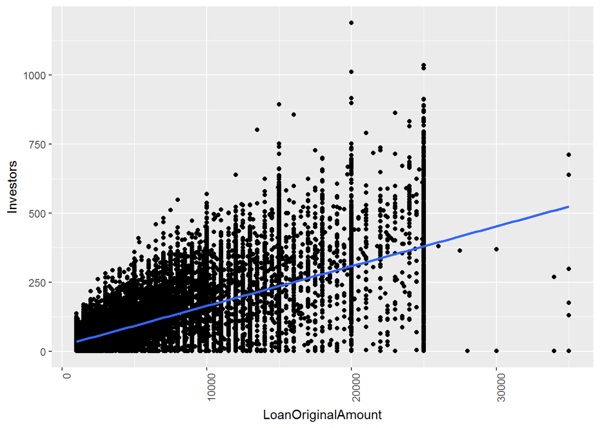

```
## [1] "> Estatísticas de Correlação entre:  Investors  x  LoanOriginalAmount"
## [1] "- Método           :  Pearson's product-moment correlation"
## [1] "- p.value          :  0.66"
## [1] "- Interv.Confiança :  0.654  /  0.666"
##
## [1] "- Observações:  Neste invertem-se os eixos do gráfico apresentado anteriormente. Apesar disso, é possível observar novamente a tendência natural de precisar de mais investidores para valores mais altos de empréstimos."
```

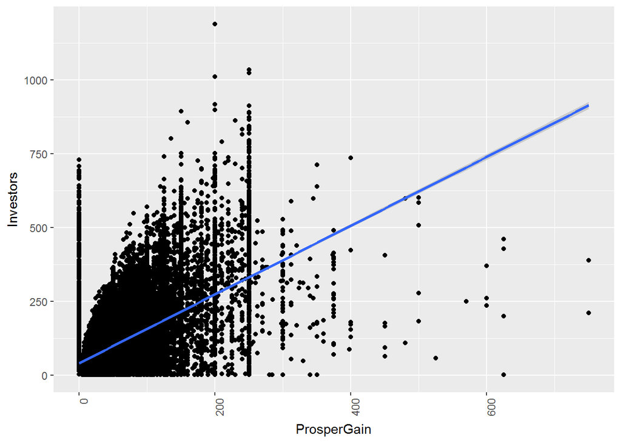

[output not shown]

## 4.2. Gráficos BoxPlot entre as variáveis de Resultado numéricas investigadas e demais variáveis (fatoriais)

> Nesta etapa foram selecionadas entre as variáveis fatoriais do conjunto de dados, aquelas que possuem maior relevância com o tema investigado. Para cada variável selecionada foram calculadas as correlações com todas as demais variáveis numéricas e estas expostas por meio de gráfico de dispersão quando as correlações apresentaram um coeficiente maior ou igual a 0,4.

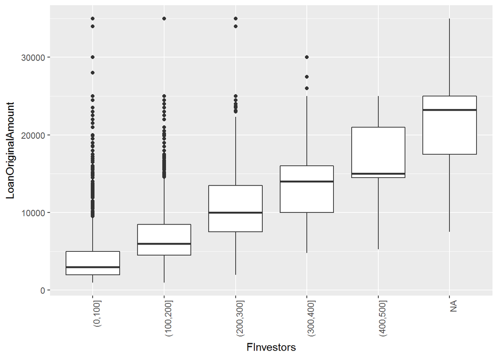

```
## [1] "> Estatísticas de Correlação entre:  FInvestors  x  LoanOriginalAmount"
## [1] "- Método           : eta squared"
## [1] "- p.value          :  0.614"
##   FInvestors    x.mean      x.sd     x.min     x.max
## 1    (0,100]  4195.464  3522.026  1000.000 35000.000
## 2  (100,200]  7029.646  3944.118  1000.000 35000.000
## 3  (200,300] 10535.494  4539.260  2000.000 35000.000
## 4  (300,400] 13932.391  4916.040  4800.000 30000.000
## 5  (400,500] 17225.189  5027.298  5300.000 25000.000
##
## [1] "- Observações:  Confirmando os resultados das correlações entre as versões numéricas das variáveis de interesse selecionadas, observa-se novamente a tendência de ocorrer um número maior de investidores para valores de empréstimos mais elevados."
```

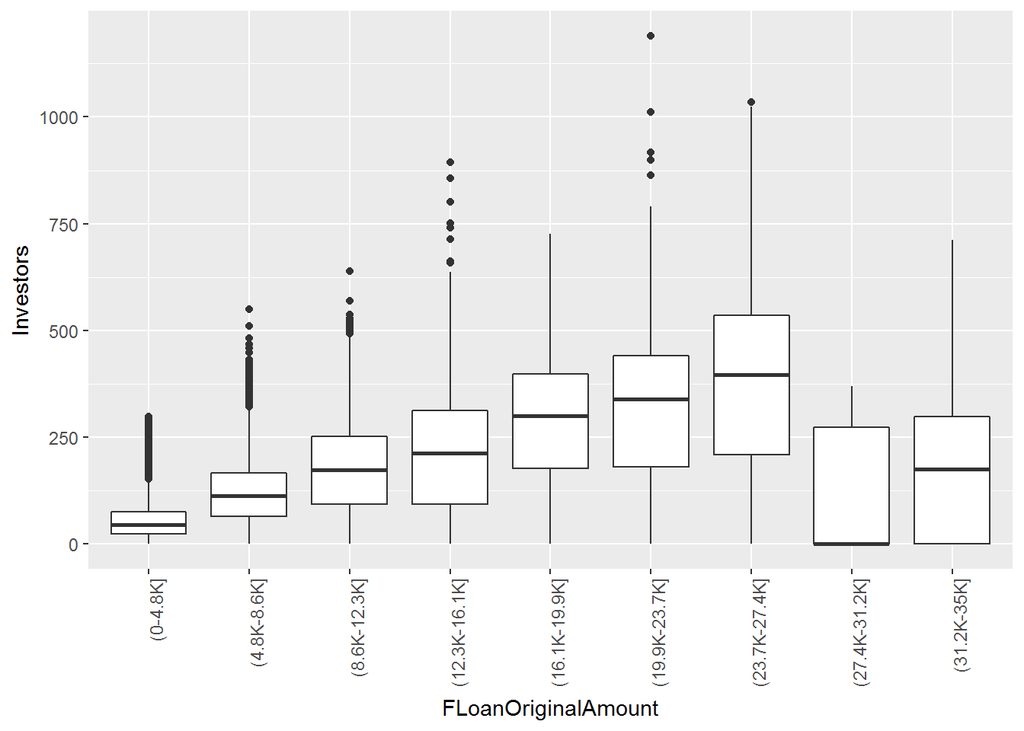

[output not shown]

# 5: ANÁLISE E SESSÃO DE GRÁFICOS MULTIVARIADOS:

## 5.1. Sessão de Gráficos Multivariados com as variáveis BorrowerAPR e CreditScoreRangeMean:

> Nesta etapa foi selecionada a variável CreditScoreRangeMean enquanto indicador da capacidade de crédito do mutuário. O objetivo é verificar o comportamento deste indicador em relação às taxas de juros anuais aprovadas (BorrowerAPR) agrupando nas categorias de cada variável fatorial disponível no conjunto de dados.

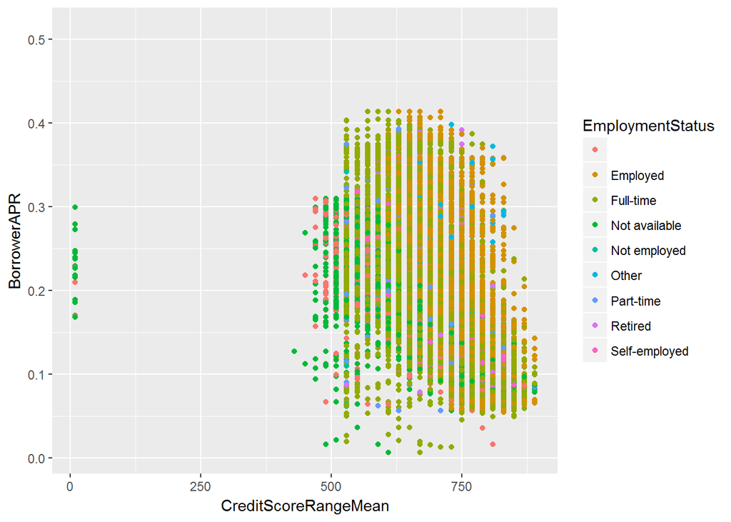

[output not shown]

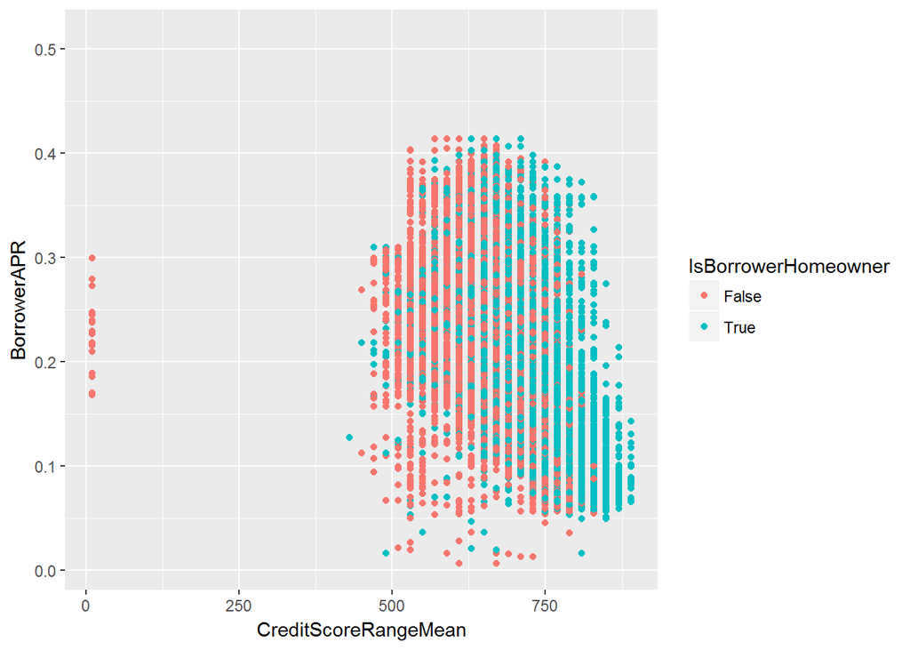

[output not shown]

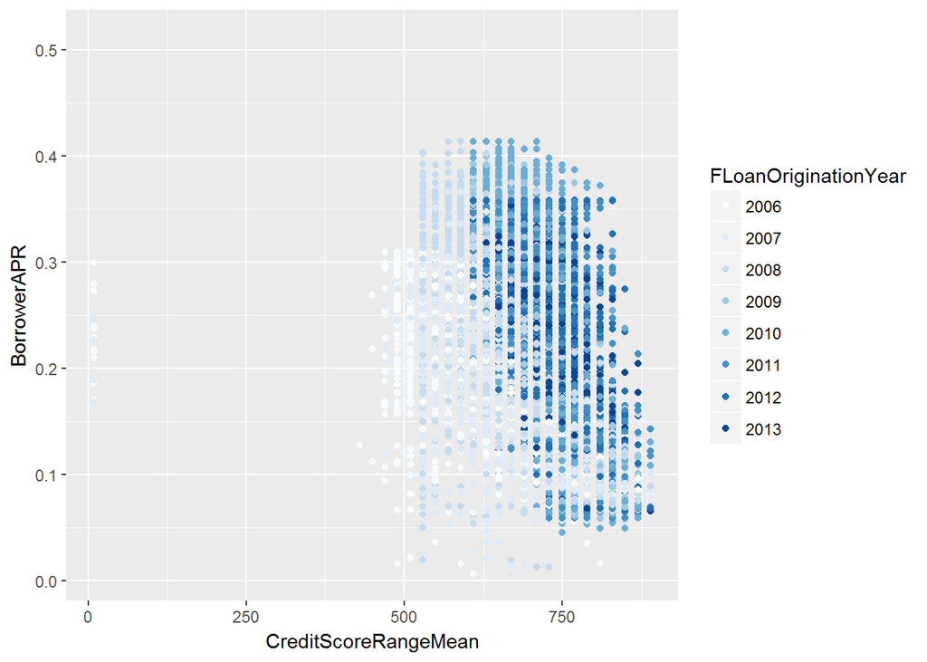

```
##
## [1] "- Observações:  Pecebe-se um aumento gradual no score de crédito ao longo dos anos."
```